# Geometric Distribution

STA 632 | Project 1

Nishan Khanal

The geometric distribution models the **number of failures before the first success** in independent trials with the same success probability. Throughout this report, $X$ counts failures and $p$ is the probability of success on each trial. This is the version used by R’s geometric functions [1].

For example, suppose each attempt to transmit a packet succeeds independently with probability $p=0.20$. If the outcomes are failure, failure, success, then $X=2$. The successful attempt is not included in the failure count. This is an illustrative model; actual transmissions need not have independent outcomes or a constant success probability.

### Discrete or Continuous?

The geometric distribution is **discrete** because it assigns probabilities to nonnegative integer counts. A probability mass function (PMF), rather than a probability density function (PDF), describes these probabilities.

### Support

For $0<p<1$, the support is

$$\mathcal{S}=\{0,1,2,3,\ldots\}.$$

Here, $\mathcal{S}$ denotes the set of possible values of $X$. In particular, $X=0$ means that the first trial succeeds. There is no finite upper bound. At the boundary $p=1$, success is certain on the first trial, so the support reduces to $\{0\}$.

### Parameters

There is one distribution parameter:

| R parameter name | Verbal name | Notation |
| --- | --- | --- |
| `prob` | Probability of success on each trial | $p$ |

In `dgeom(x, prob)`, `x` is a failure count at which to evaluate the PMF; it is not a distribution parameter. Similarly, `n` in `rgeom(n, prob)` specifies how many observations to simulate, not the number of trials before success.

### Parameter space

The parameter space accepted by R is $0<p\leq 1$ [1]. When $p=1$, all probability is at zero. The value $p=0$ is excluded: success never occurs, so there is no finite failure count before the first success.

### PDF or PMF formula

For $0<p<1$, the PMF is

$$f_X(x)=P(X=x)=
\begin{cases}
p(1-p)^x, & x=0,1,2,\ldots,\\
0, & \text{otherwise}.
\end{cases}$$

Here, $f_X(x)$ is the probability of exactly $x$ failures before the first success. The factor $(1-p)^x$ is the probability of $x$ consecutive failures; the final factor $p$ is the probability that the next trial succeeds. Independence lets us multiply these probabilities. At $p=1$, define $f_X(0)=1$ and $f_X(x)=0$ for every $x\neq 0$.

The probabilities sum to one by the geometric-series identity:

$$\sum_{x=0}^{\infty}p(1-p)^x
=\frac{p}{1-(1-p)}=1.$$

### Mean and variance

The mean, variance, and standard deviation are

$$\mu=E(X)=\frac{1-p}{p},\qquad
\sigma^2=\operatorname{Var}(X)=\frac{1-p}{p^2},\qquad
\sigma=\frac{\sqrt{1-p}}{p}.$$

Here, $E(X)$ or $\mu$ is the long-run average number of failures, $\operatorname{Var}(X)$ or $\sigma^2$ measures spread in squared failure-count units, and $\sigma$ measures spread in failure-count units. These formulas also give zero mean and variance when $p=1$.

For $p=0.20$, the mean is $4$ failures, the variance is $20$, and the standard deviation is approximately $4.472$ failures. The mean is a long-run average, not a guarantee that each sequence has four failures.

**The other convention.** If $T$ counts the total trials up to and including the first success, then

$$T=X+1,\qquad E(T)=\frac{1}{p},\qquad
\operatorname{Var}(T)=\operatorname{Var}(X).$$

Thus, $T$ starts at $1$, while $X$ starts at $0$. Adding one changes the mean but not the variance. Some references, including [3], use the $T$ convention. With $p=0.20$, the expected total number of attempts is $5$.

### Plot of probability mass function

The following plots compare **four parameter values**: $p=0.20,0.40,0.60,0.80$. Vertical segments and points emphasize that probability is assigned only to integers, following the discrete plots in Activities 1.2 through 1.4. All panels use the same axes to make comparisons meaningful.

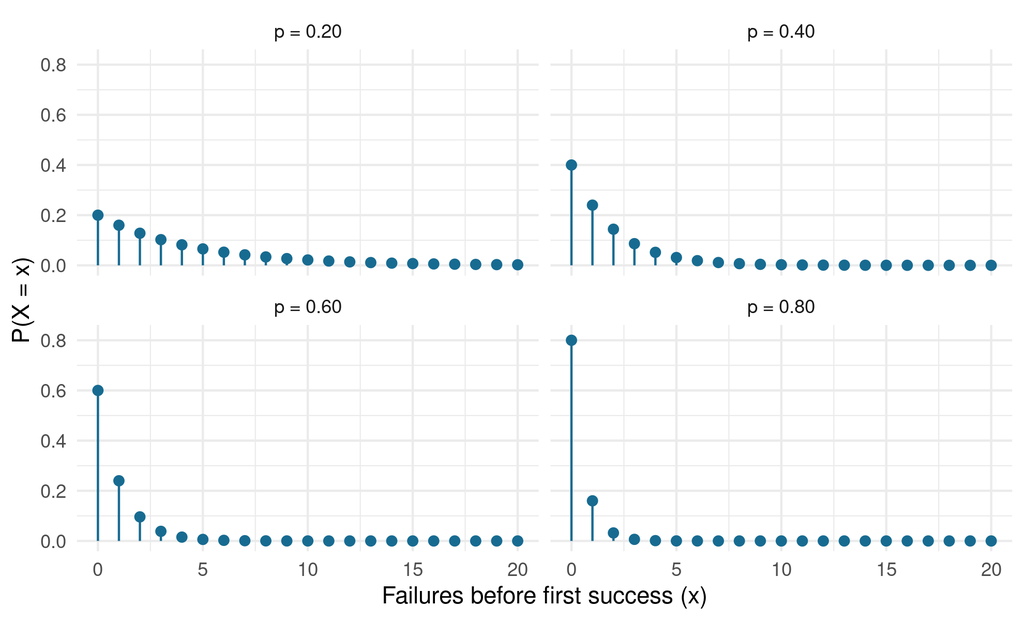

Geometric PMFs for four success probabilities; X counts failures.

```r
prob_values <- c(0.20, 0.40, 0.60, 0.80)
pmf_dat <- expand.grid(x = 0:20, prob = prob_values)
pmf_dat$pmf <- dgeom(pmf_dat$x, prob = pmf_dat$prob)
pmf_dat$panel <- factor(
  pmf_dat$prob, levels = prob_values,
  labels = paste0("p = ", sprintf("%.2f", prob_values))
)

ggplot(pmf_dat, aes(x = x, y = pmf)) +
  geom_segment(aes(xend = x, yend = 0), color = "#176B91") +
  geom_point(color = "#176B91", size = 1.8) +
  facet_wrap(~panel, ncol = 2) +
  scale_x_continuous(breaks = seq(0, 20, by = 5)) +
  scale_y_continuous(limits = c(0, 0.82)) +
  labs(x = "Failures before first success (x)",
       y = "P(X = x)")
```

The display stops at $20$, but the support continues indefinitely. Even for $p=0.20$, the displayed values contain 99.08% of the probability; the omitted tail has probability $P(X>20)=(0.80)^{21}\approx 0.00922$.

| p | Mean | Variance | SD |
| --- | --- | --- | --- |
| 0.2 | 4.000 | 20.000 | 4.472 |
| 0.4 | 1.500 | 3.750 | 1.936 |
| 0.6 | 0.667 | 1.111 | 1.054 |
| 0.8 | 0.250 | 0.312 | 0.559 |

### How does the distribution change with the parameters?

- **Center:** Increasing $p$ lowers the mean $(1-p)/p$. Success tends to occur sooner, so fewer failures are expected.
- **Spread:** Increasing $p$ decreases both the variance and the standard deviation. Small $p$ allows much longer and more variable waits.
- **Shape:** For $0<p<1$, the PMF is decreasing and right-skewed, with its unique mode at $0$. The ratio of successive masses is $f_X(x+1)/f_X(x)=1-p$. A larger $p$ makes the PMF fall more quickly and puts more mass at zero; a smaller $p$ gives a more slowly decaying tail. A shorter tail here does not mean that the distribution becomes symmetric.
- **Boundary behavior:** As $p$ approaches $1$, the distribution concentrates at zero. As $p$ approaches $0$ from above, the mean and variance grow without bound.

### Distribution-specific questions

#### What are Bernoulli trials, and how are they related to the geometric distribution?

A Bernoulli trial has two possible outcomes, labeled **success** and **failure**. These labels identify outcomes and do not necessarily mean something desirable or undesirable. A sequence of Bernoulli trials for the geometric model has three features:

1. Each trial has two possible outcomes.
2. Trials are independent: previous outcomes do not affect the next trial.
3. Every trial has the same success probability $p$.

The geometric random variable counts failures until the first success in this sequence. For example, with repeated independent rolls of a fair die, define success as rolling a six. Then $p=1/6$ and $X$ counts non-six results before the first six. Its mean is $(1-1/6)/(1/6)=5$ failures.

Sampling without replacement from a finite population generally does not satisfy the constant-probability assumption. Likewise, a process whose success probability changes through learning or fatigue need not be geometric.

#### How is the geometric distribution related to the negative binomial distribution?

For a positive integer $r$, let $Y$ count failures before the **$r$th success** in independent Bernoulli trials with success probability $p$. Then $Y$ has a negative binomial distribution [2], with PMF

$$P(Y=y)=\binom{y+r-1}{y}p^r(1-p)^y,
\qquad y=0,1,2,\ldots.$$

Here, $y$ is the number of failures, $r$ is the target number of successes (`size` in R), and $p$ is `prob`. The binomial coefficient counts arrangements of $y$ failures and $r-1$ successes before the final successful trial.

Setting $r=1$ gives

$$P(Y=y)=\binom{y}{y}p(1-p)^y=p(1-p)^y.$$

Therefore, the **geometric distribution is the negative binomial distribution with `size = 1`**. This identity can be checked in R:

```r
x_check <- 0:20
all.equal(
  dgeom(x_check, prob = 0.20),
  dnbinom(x_check, size = 1, prob = 0.20)
)
```

```
## [1] TRUE
```

R also allows positive noninteger `size` values, but the literal interpretation as a target number of successes uses integer $r$ [2]. The distributions differ from the binomial as follows:

| Distribution | What is fixed? | What is counted? |
| --- | --- | --- |
| Binomial | Number of trials | Successes in those trials |
| Negative binomial | Target successes, $r$ | Failures before the $r$th success |
| Geometric | One target success | Failures before the first success |

#### What is the memoryless property? Explain using conditional probability.

Once several trials have failed, the distribution of the **additional** failures before success is the same as it was at the start. Past failures do not make success more or less likely on the next independent trial.

For our failure-count variable $X$, the appropriate statement is

$$P(X\geq m+n\mid X\geq m)=P(X\geq n),
\qquad m,n\in\{0,1,2,\ldots\},\quad 0<p<1.$$

Here, $m$ is the number of failures already observed, $n$ is an additional failure threshold, and the vertical bar means “given that.” The event $X\geq m$ means that the first $m$ trials all failed. Since $P(X\geq k)=(1-p)^k$ for any nonnegative integer $k$, conditional probability gives

$$\begin{aligned}
P(X\geq m+n\mid X\geq m)
&=\frac{P(X\geq m+n)}{P(X\geq m)}\\
&=\frac{(1-p)^{m+n}}{(1-p)^m}\\
&=(1-p)^n=P(X\geq n).
\end{aligned}$$

The numerator simplifies because $X\geq m+n$ implies $X\geq m$. For $p=1$ and $m\geq1$, the conditioning event has probability zero, so this conditional probability is undefined.

**Numerical example.** If $p=0.20$ and the first three attempts fail, the probability that the next four attempts also fail is

$$P(X\geq7\mid X\geq3)=(0.80)^4=0.4096.$$

```r
p_success <- 0.20
m <- 3
n_more <- 4
# pgeom(k - 1, lower.tail = FALSE) gives P(X >= k).
conditional_prob <-
  pgeom(m + n_more - 1, prob = p_success, lower.tail = FALSE) /
  pgeom(m - 1, prob = p_success, lower.tail = FALSE)
fresh_prob <- pgeom(n_more - 1, prob = p_success,
                    lower.tail = FALSE)
c(Conditional = conditional_prob, Fresh_start = fresh_prob)
```

```
## Conditional Fresh_start
##      0.4096      0.4096
```

**Counting distinction:** The familiar strict-inequality form $P(T>m+n\mid T>m)=P(T>n)$ applies to $T=X+1$, which counts total trials. For the failure count $X$, use the $\geq$ form shown above to avoid an off-by-one error. Memorylessness concerns the remaining wait, not the total number of failures accumulated so far.

### R distribution functions: d, p, q, and r

Following Activities 1.1 and 1.2, the four geometric functions are [1]:

| Function | Purpose |
| --- | --- |
| `dgeom(x, prob)` | Exact probability $P(X=x)$ |
| `pgeom(q, prob)` | Cumulative probability $P(X\leq q)$ |
| `qgeom(p, prob)` | Smallest failure count reaching a target cumulative probability |
| `rgeom(n, prob)` | Generate $n$ independent geometric observations |

The argument `p` in **`qgeom(p, prob)`** is the requested cumulative probability; `prob` is the per-trial success probability. They are different quantities. The next examples use `p_success = 0.20`.

#### Cumulative distribution function (CDF)

For a real number $x$, the CDF is

$$F_X(x)=P(X\leq x)=
\begin{cases}
0, & x<0,\\
1-(1-p)^{\lfloor x\rfloor+1}, & x\geq0.
\end{cases}$$

Here, $F_X$ denotes the CDF, and $\lfloor x\rfloor$ is the greatest integer less than or equal to $x$. For example, $F_X(2.5)=F_X(2)$ because no possible failure counts lie between $2$ and $3$. At each nonnegative integer, the CDF jumps by the probability mass at that integer.

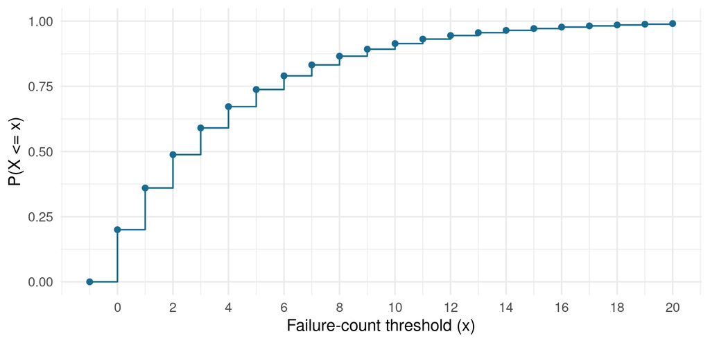

The geometric CDF is constant between consecutive integers (p = 0.20).

```r
cdf_dat <- data.frame(x = -1:20)
cdf_dat$cdf <- pgeom(cdf_dat$x, prob = p_success)
ggplot(cdf_dat, aes(x = x, y = cdf)) +
  geom_step(direction = "hv", color = "#176B91") +
  geom_point(color = "#176B91", size = 1.5) +
  scale_y_continuous(limits = c(0, 1)) +
  scale_x_continuous(breaks = seq(0, 20, by = 2)) +
  labs(x = "Failure-count threshold (x)", y = "P(X <= x)")
```

#### Probability examples

Using the packet-transmission example with $p=0.20$:

```r
prob_examples <- data.frame(
  Event = c("Exactly 3 failures", "At most 3 failures",
            "More than 4 failures", "2 to 5 failures, inclusive"),
  Probability = c(
    dgeom(3, prob = p_success),
    pgeom(3, prob = p_success),
    pgeom(4, prob = p_success, lower.tail = FALSE),
    pgeom(5, prob = p_success) - pgeom(1, prob = p_success)
  )
)
knitr::kable(prob_examples, digits = 6)
```

| Event | Probability |
| --- | --- |
| Exactly 3 failures | 0.102400 |
| At most 3 failures | 0.590400 |
| More than 4 failures | 0.327680 |
| 2 to 5 failures, inclusive | 0.377856 |

The first row, $P(X=3)=0.1024$, means that the first success occurs on **attempt 4**. For the interval probability, subtract $P(X\leq1)$ from $P(X\leq5)$ so that $X=2$ remains included. Also note that `lower.tail = FALSE` returns $P(X>q)$, not $P(X\geq q)$.

#### Quantile example

How many attempts are needed for at least a $90\%$ chance of seeing a success? Let $u=0.90$ be the target cumulative probability. The failure-count quantile $Q(u)$ is the smallest nonnegative integer $k$ for which $F_X(k)\geq u$.

```r
u <- 0.90
failure_quantile <- qgeom(p = u, prob = p_success)
data.frame(
  Failure_quantile = failure_quantile,
  Attempts_needed = failure_quantile + 1,
  CDF_at_previous = pgeom(failure_quantile - 1, prob = p_success),
  CDF_at_quantile = pgeom(failure_quantile, prob = p_success)
)
```

| Failure_quantile | Attempts_needed | CDF_at_previous | CDF_at_quantile |
| --- | --- | --- | --- |
| 10 | 11 | 0.8926258 | 0.9141007 |

The 90th percentile is **10 failures**, corresponding to **11 attempts**. The chance of success within 10 attempts is about $0.8926$, while within 11 attempts it is about $0.9141$. Because the CDF jumps, the probability at the quantile can exceed $0.90$; it need not equal the target exactly.

#### Random generation and comparison with theory

Each simulated observation is the failure count from a separate sequence that ends at its first success. Setting a seed makes the simulation reproducible. The sample mean, variance, and standard deviation should be close to their theoretical values, with some sampling variation.

```r
set.seed(632)
simulated_x <- rgeom(n = 10000, prob = p_success)
simulation_summary <- data.frame(
  Quantity = c("Mean", "Variance", "Standard deviation"),
  Theoretical = c((1 - p_success) / p_success,
                  (1 - p_success) / p_success^2,
                  sqrt(1 - p_success) / p_success),
  Simulated = c(mean(simulated_x), var(simulated_x), sd(simulated_x))
)
knitr::kable(simulation_summary, digits = 3)
```

| Quantity | Theoretical | Simulated |
| --- | --- | --- |
| Mean | 4.000 | 4.047 |
| Variance | 20.000 | 20.374 |
| Standard deviation | 4.472 | 4.514 |